# DA5030.P2.Karwarkar

# Problem 2 (25 Points)

# After reading the case study background information, using the UFFI data set, answer these questions:

# (5 pts) Are there outliers in the data set? How do you identify outliers and how do you deal with them? Remove them but create a second data set with outliers removed. Keep the original data set.

```r
library(xlsx)
uffi <- read.xlsx("uffidata.xlsx",sheetName= "Sales Data")
#We use the read.xlsx function to read the dataset and specify the sheet name
```

```r
new <- uffi[!uffi %in% boxplot.stats(uffi)$out]
```

```r
identical(uffi,new)
```

```
[1] TRUE
```

```r
#Here we first load the uffi dataset and check for outliers
#After creating a new dataset with removed outliers, we check if the two tables are identical
#The TRUE identical result shows that both the tables are same and the dataset did not have outliers
#Here we use bosplot.stats to identify and remove outliers
#There are several other functions as well to remove outliers
#boxplot and quartile ranges are also a method to find the outliers
```

# (2 pts) What are the correlations to the response variable and are there colinearities? Build a full correlation matrix.

```
$`r`
               UFFI.IN X45.Yrs. Bsmnt.Fin_SF Central.Air Observation Brick.Ext   Pool Enc.Pk.Spaces Year.Sold
UFFI.IN          1.000   0.0730      -0.0630      -0.012     0.04400   -0.0030 -0.097      -0.12000    -0.230
X45.Yrs.         0.073   1.0000      -0.4700      -0.140    -0.67000   -0.2100 -0.220      -0.01700    -0.150
Bsmnt.Fin_SF    -0.063  -0.4700       1.0000       0.300     0.29000   -0.0850  0.120      -0.00910     0.110
Central.Air     -0.012  -0.1400       0.3000       1.000     0.18000    0.0230  0.033       0.12000     0.047
Observation      0.044  -0.6700       0.2900       0.180     1.00000    0.2300  0.120       0.00051    -0.014
Brick.Ext       -0.003  -0.2100      -0.0850       0.023     0.23000    1.0000 -0.022      -0.04500     0.200
Pool            -0.097  -0.2200       0.1200       0.033     0.12000   -0.0220  1.000       0.13000     0.120
Enc.Pk.Spaces   -0.120  -0.0170      -0.0091       0.120     0.00051   -0.0450  0.130       1.00000     0.270
Year.Sold       -0.230  -0.1500       0.1100       0.047    -0.01400    0.2000  0.120       0.27000     1.000
Lot.Area         0.160  -0.3400       0.2200       0.290     0.15000    0.0077  0.090       0.27000     0.270
Sale.Price      -0.130  -0.2000       0.1100       0.220     0.11000    0.2100  0.430       0.49000     0.570
Living.Area_SF   0.045   0.0075      -0.0770       0.160    -0.00700    0.1400  0.190       0.39000     0.350
               Lot.Area Sale.Price Living.Area_SF
UFFI.IN          0.1600      -0.13         0.0450
X45.Yrs.        -0.3400      -0.20         0.0075
Bsmnt.Fin_SF     0.2200       0.11        -0.0770
Central.Air      0.2900       0.22         0.1600
Observation      0.1500       0.11        -0.0070
Brick.Ext        0.0077       0.21         0.1400
Pool             0.0900       0.43         0.1900
Enc.Pk.Spaces    0.2700       0.49         0.3900
Year.Sold        0.2700       0.57         0.3500
Lot.Area         1.0000       0.45         0.3900
Sale.Price       0.4500       1.00         0.7200
Living.Area_SF   0.3900       0.72         1.0000

$p
               UFFI.IN X45.Yrs. Bsmnt.Fin_SF Central.Air Observation Brick.Ext    Pool Enc.Pk.Spaces Year.Sold
UFFI.IN          0.000  4.7e-01      5.4e-01      0.9100     6.6e-01     0.980 3.4e-01       2.2e-01   2.2e-02
X45.Yrs.         0.470  0.0e+00      1.0e-06      0.1700     4.2e-14     0.037 2.7e-02       8.7e-01   1.4e-01
Bsmnt.Fin_SF     0.540  1.0e-06      0.0e+00      0.0030     3.3e-03     0.400 2.5e-01       9.3e-01   3.0e-01
Central.Air      0.910  1.7e-01      3.0e-03      0.0000     7.1e-02     0.820 7.5e-01       2.5e-01   6.4e-01
Observation      0.660  4.2e-14      3.3e-03      0.0710     0.0e+00     0.022 2.4e-01       1.0e+00   8.9e-01
Brick.Ext        0.980  3.7e-02      4.0e-01      0.8200     2.2e-02     0.000 8.3e-01       6.6e-01   5.3e-02
Pool             0.340  2.7e-02      2.5e-01      0.7500     2.4e-01     0.830 0.0e+00       1.9e-01   2.5e-01
Enc.Pk.Spaces    0.220  8.7e-01      9.3e-01      0.2500     1.0e+00     0.660 1.9e-01       0.0e+00   7.0e-03
Year.Sold        0.022  1.4e-01      3.0e-01      0.6400     8.9e-01     0.053 2.5e-01       7.0e-03   0.0e+00
Lot.Area         0.110  6.9e-04      2.9e-02      0.0038     1.4e-01     0.940 3.8e-01       7.3e-03   6.8e-03
```

[output cut: 30 more lines]

```
               Lot.Area Sale.Price Living.Area_SF
UFFI.IN
X45.Yrs.
Bsmnt.Fin_SF
Central.Air
Observation
Brick.Ext
Pool
Enc.Pk.Spaces
Year.Sold
Lot.Area       1
Sale.Price     .        1
Living.Area_SF .        ,          1
attr(,"legend")
[1] 0   0.3 . 0.6 , 0.8 + 0.9 * 0.95 B 1
```

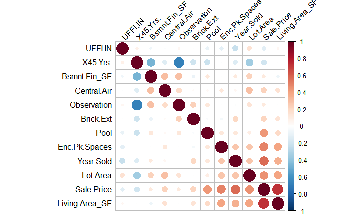

```r
library(corrplot)
source("http://www.sthda.com/upload/rquery_cormat.r")
rquery.cormat(uffi, type="full")
```

```r
#Here we use the function rquery.cormat to create a full correlation matrix
```